# Методы кластеризации и обучение на неразмеченных данных

## Библиотеки

```python
import matplotlib.pyplot as plt
from matplotlib.image import imread
from mpl_toolkits import mplot3d
from matplotlib import gridspec
from copy import deepcopy
from mlxtend.plotting import plot_decision_regions
import seaborn as sns
import pandas as pd
from tqdm.notebook import tqdm
from scipy.spatial.distance import cdist
from scipy import stats
import numpy as np
from sklearn import tree, base
import itertools
from sklearn.tree import DecisionTreeClassifier, DecisionTreeRegressor
from sklearn.ensemble import (RandomForestClassifier, AdaBoostClassifier,
                              GradientBoostingClassifier, BaggingClassifier)
from sklearn.svm import SVC, SVR
from sklearn.linear_model import LogisticRegression, LinearRegression
from sklearn.metrics import classification_report, roc_auc_score, roc_curve
from sklearn.model_selection import KFold, ParameterGrid
from sklearn.model_selection import cross_val_score, RepeatedStratifiedKFold, RepeatedKFold
from sklearn.datasets import make_classification, make_regression, load_wine, load_boston
from sklearn.model_selection import train_test_split
from sklearn.decomposition import PCA
from torchvision import datasets, transforms
import torch

from sklearn.cluster import KMeans, DBSCAN, AgglomerativeClustering
from scipy.cluster.hierarchy import dendrogram
```

```python
colors = ['blue', 'red', 'green', 'orange', 'magenta', 'black', 'cyan', 'purple']
```

## Задача кластеризации

Найти:

- $Y$ --- множество кластеров
- $a: X \to Y$ --- алгоритм кластеризации
  - каждый класстер состоит из близкихобъектов
  - объекты разных кластеров существенно различны.

## Примеры

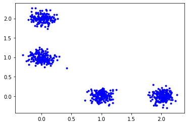

```python
_ = plt.plot(X[:, 0], X[:, 1], '.', color=colors[0])

plt.show()
```

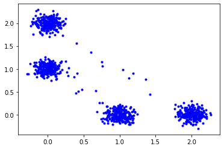

```python
_ = plt.plot(X[:, 0], X[:, 1], '.', color=colors[0])

plt.show()
```

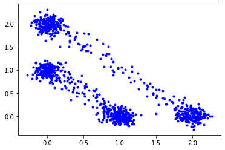

```python
_ = plt.plot(X[:, 0], X[:, 1], '.', color=colors[0])

plt.show()
```

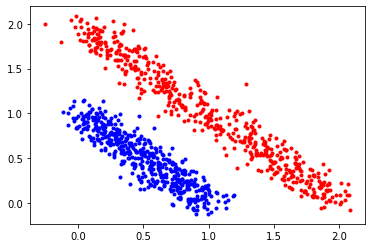

```python
np.random.seed(0)
l = 500
X_1 = np.random.dirichlet([1e-0, 1e-0], size = l) \
      + 1e-1*np.random.randn(l, 2)
X_2 = 2*np.random.dirichlet([1e-0, 1e-0], size = l) \
      + 1e-1*np.random.randn(l, 2)

_ = plt.plot(X_1[:, 0], X_1[:, 1], '.', color=colors[0])
_ = plt.plot(X_2[:, 0], X_2[:, 1], '.', color=colors[1])

plt.show()
```

## K-Means

```python
np.random.seed(0)
l = 50
X_1 = np.random.dirichlet([1e-0, 1e-0], size = l) \
      + 1e-1*np.random.randn(l, 2)
X_2 = 2*np.random.dirichlet([1e-0, 1e-0], size = l) \
      + 1e-1*np.random.randn(l, 2)

X = np.vstack([X_1, X_2])

_ = plt.plot(X[:, 0], X[:, 1], '.', color=colors[0])
plt.show()
```

[output not shown]

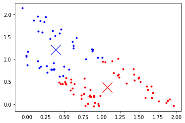

```python
model = KMeans(n_clusters=2, random_state=42)
model.fit(X)

for i in np.unique(model.labels_):
    _ = plt.plot(X[model.labels_ == i, 0],
                 X[model.labels_ == i, 1], '.', color=colors[i])
    _ = plt.plot([model.cluster_centers_[i][0]],
                 [model.cluster_centers_[i][1]], 'x', c=colors[i], markersize=20)
```

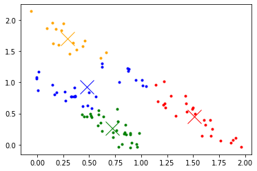

```python
model = KMeans(n_clusters=4, random_state=42)
model.fit(X)

for i in np.unique(model.labels_):
    _ = plt.plot(X[model.labels_ == i, 0],
                 X[model.labels_ == i, 1], '.', color=colors[i])
    _ = plt.plot([model.cluster_centers_[i][0]],
                 [model.cluster_centers_[i][1]], 'x', c=colors[i], markersize=20)
```

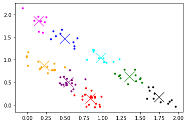

```python
model = KMeans(n_clusters=8, random_state=42)
model.fit(X)

for i in np.unique(model.labels_):
    _ = plt.plot(X[model.labels_ == i, 0],
                 X[model.labels_ == i, 1], '.', color=colors[i])
    _ = plt.plot([model.cluster_centers_[i][0]],
                 [model.cluster_centers_[i][1]], 'x', c=colors[i], markersize=20)
```

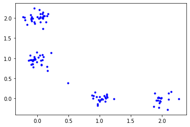

```python
np.random.seed(0)
l = 50
X_1 = np.random.dirichlet([1e-2, 1e-2], size = l) \
      + 1e-1*np.random.randn(l, 2)
X_2 = 2*np.random.dirichlet([1e-2, 1e-2], size = l) \
      + 1e-1*np.random.randn(l, 2)

X = np.vstack([X_1, X_2])

_ = plt.plot(X[:, 0], X[:, 1], '.', color=colors[0])
plt.show()
```

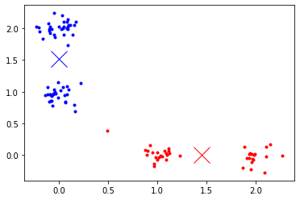

```python
model = KMeans(n_clusters=2, random_state=42)
model.fit(X)

for i in np.unique(model.labels_):
    _ = plt.plot(X[model.labels_ == i, 0],
                 X[model.labels_ == i, 1], '.', color=colors[i])
    _ = plt.plot([model.cluster_centers_[i][0]],
                 [model.cluster_centers_[i][1]], 'x', c=colors[i], markersize=20)
```

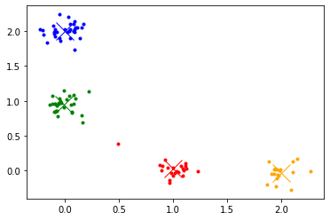

```python
model = KMeans(n_clusters=4, random_state=42)
model.fit(X)

for i in np.unique(model.labels_):
    _ = plt.plot(X[model.labels_ == i, 0],
                 X[model.labels_ == i, 1], '.', color=colors[i])
    _ = plt.plot([model.cluster_centers_[i][0]],
                 [model.cluster_centers_[i][1]], 'x', c=colors[i], markersize=20)
```

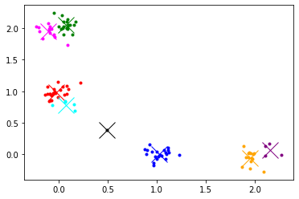

```python
model = KMeans(n_clusters=8, random_state=42)
model.fit(X)

for i in np.unique(model.labels_):
    _ = plt.plot(X[model.labels_ == i, 0],
                 X[model.labels_ == i, 1], '.', color=colors[i])
    _ = plt.plot([model.cluster_centers_[i][0]],
                 [model.cluster_centers_[i][1]], 'x', c=colors[i], markersize=20)
```

### Ограничения

Работает с Евклидовой метрикой и только!

## DBSCAN

```python
np.random.seed(0)
l = 50
X_1 = np.random.dirichlet([1e-0, 1e-0], size = l) \
      + 1e-1*np.random.randn(l, 2)
X_2 = 2*np.random.dirichlet([1e-0, 1e-0], size = l) \
      + 1e-1*np.random.randn(l, 2)

X = np.vstack([X_1, X_2])

_ = plt.plot(X[:, 0], X[:, 1], '.', color=colors[0])
plt.show()
```

[output not shown]

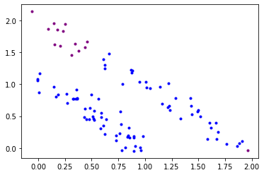

```python
model = DBSCAN(0.5, min_samples=20)
model.fit(X)

for i in np.unique(model.labels_):
    _ = plt.plot(X[model.labels_ == i, 0],
                 X[model.labels_ == i, 1], '.', color=colors[i])
```

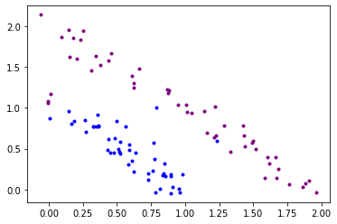

```python
model = DBSCAN(0.5, min_samples=20, metric='minkowski', p=1)
model.fit(X)

for i in np.unique(model.labels_):
    _ = plt.plot(X[model.labels_ == i, 0],
                 X[model.labels_ == i, 1], '.', color=colors[i])
```

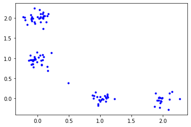

```python
np.random.seed(0)
l = 50
X_1 = np.random.dirichlet([1e-2, 1e-2], size = l) \
      + 1e-1*np.random.randn(l, 2)
X_2 = 2*np.random.dirichlet([1e-2, 1e-2], size = l) \
      + 1e-1*np.random.randn(l, 2)

X = np.vstack([X_1, X_2])

_ = plt.plot(X[:, 0], X[:, 1], '.', color=colors[0])
plt.show()
```

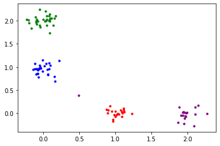

```python
model = DBSCAN(0.5, min_samples=20, metric='minkowski', p=1)
model.fit(X)

for i in np.unique(model.labels_):
    _ = plt.plot(X[model.labels_ == i, 0],
                 X[model.labels_ == i, 1], '.', color=colors[i])
```

## Иерархическая кластеризация (Ланс, Уильямс, 1967)

```python
np.random.seed(0)
l = 50
X_1 = np.random.dirichlet([1e-0, 1e-0], size = l) \
      + 1e-1*np.random.randn(l, 2)
X_2 = 2*np.random.dirichlet([1e-0, 1e-0], size = l) \
      + 1e-1*np.random.randn(l, 2)

X = np.vstack([X_1, X_2])

_ = plt.plot(X[:, 0], X[:, 1], '.', color=colors[0])
plt.show()
```

[output not shown]

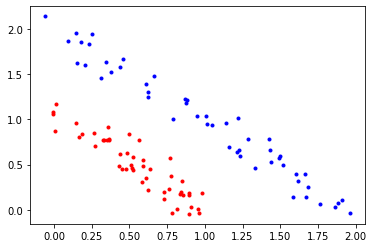

```python
model = AgglomerativeClustering(n_clusters=2, affinity='l1', linkage='single')
model.fit(X)

for i in np.unique(model.labels_):
    _ = plt.plot(X[model.labels_ == i, 0],
                 X[model.labels_ == i, 1], '.', color=colors[i])
```

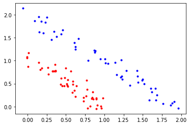

```python
model = AgglomerativeClustering(n_clusters=2, affinity='euclidean', linkage='single')
model.fit(X)

for i in np.unique(model.labels_):
    _ = plt.plot(X[model.labels_ == i, 0],
                 X[model.labels_ == i, 1], '.', color=colors[i])
```

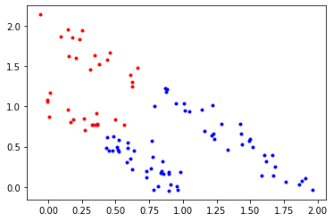

```python
model = AgglomerativeClustering(n_clusters=2, affinity='euclidean', linkage='ward')
model.fit(X)

for i in np.unique(model.labels_):
    _ = plt.plot(X[model.labels_ == i, 0],
                 X[model.labels_ == i, 1], '.', color=colors[i])
```

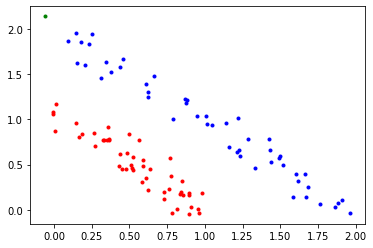

```python
model = AgglomerativeClustering(distance_threshold=0.35, n_clusters=None, affinity='l1', linkage='single')
model.fit(X)

for i in np.unique(model.labels_):
    _ = plt.plot(X[model.labels_ == i, 0],
                 X[model.labels_ == i, 1], '.', color=colors[i])
```

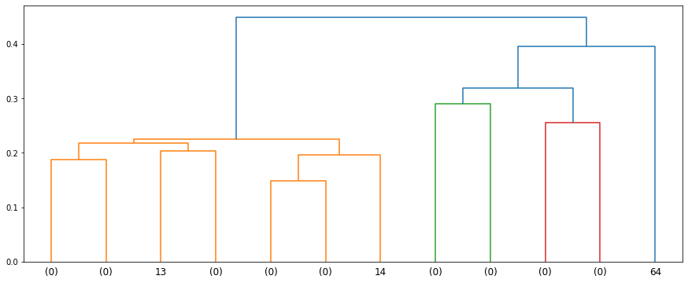

```python
counts = np.zeros(model.children_.shape[0])
linkage_matrix = np.column_stack([model.children_, model.distances_,
                                      counts]).astype(float)

fig = plt.figure(figsize=(15, 6))
dendrogram(linkage_matrix, truncate_mode='level', p=3)
plt.show()
```

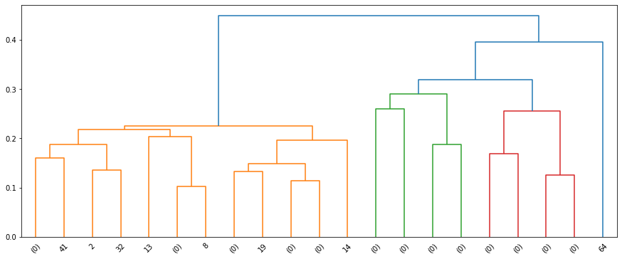

```python
counts = np.zeros(model.children_.shape[0])
linkage_matrix = np.column_stack([model.children_, model.distances_,
                                      counts]).astype(float)

fig = plt.figure(figsize=(15, 6))
dendrogram(linkage_matrix, truncate_mode='level', p=4)
plt.show()
```

### Сравнение разных подтипов

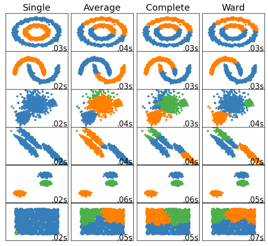

```python
sklearn_example()
```

## Пример из sklearn

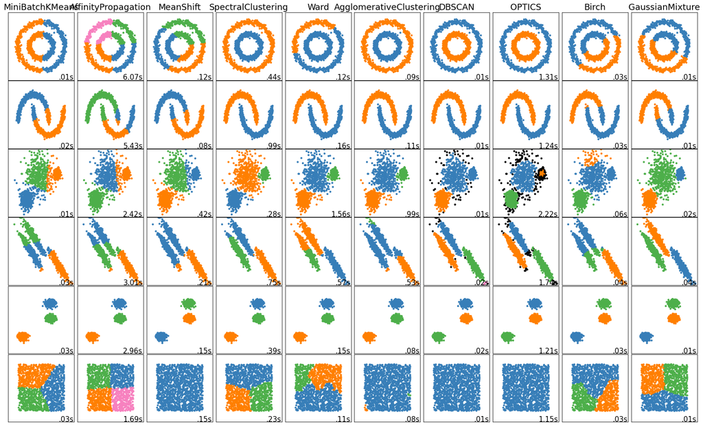

```python
sklearn_example()
```

## Частичное обучение

Дано:

- $X^k = \{x_1, \cdots, x_l\}$ --- размеченные объекты метками $\{y_1, \cdots, y_k\}$
- $U= \{x_{k+1}, \cdots, x_l\}$ --- неразмеченные объекты.

Требуется построить алгоритм $a: X \to Y$.

### Self-training, 1970

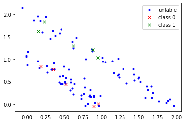

```python
np.random.seed(0)
l = 50
X_1 = np.random.dirichlet([1e-0, 1e-0], size = l) \
      + 1e-1*np.random.randn(l, 2)
X_2 = 2*np.random.dirichlet([1e-0, 1e-0], size = l) \
      + 1e-1*np.random.randn(l, 2)

U = np.vstack([X_1[:45], X_2[:45]])
Y = np.hstack([np.zeros(len(X_1[45:]), dtype=int),
               np.ones(len(X_2[45:]), dtype=int)])
X = np.vstack([X_1[45:], X_2[45:]])


_ = plt.plot(U[:, 0], U[:, 1], '.', color=colors[0], label='unlable')
for i in np.unique(Y):
    _ = plt.plot(X[Y==i, 0], X[Y==i, 1], 'x', color=colors[i+1], label='class {}'.format(i))

plt.legend(loc='best')
plt.show()
```

```python
threshold = 0.85
models = []
datas = []
used_indexes = set()
classes = np.array([], dtype=int)

for i in range(16):
    X_new = np.vstack([X, U[list(used_indexes)]])
    Y_new = np.hstack([Y, classes[list(used_indexes)]])
    datas.append((X_new, Y_new, list(used_indexes), list(classes)))
    models.append(SVC(probability=True, kernel='linear').fit(X_new, Y_new))

    probas = models[-1].predict_proba(U)
    classes = np.array(models[-1].predict(U), dtype=int)

    used_indexes |= set(np.where(np.max(probas, axis=1) > threshold)[0])
```

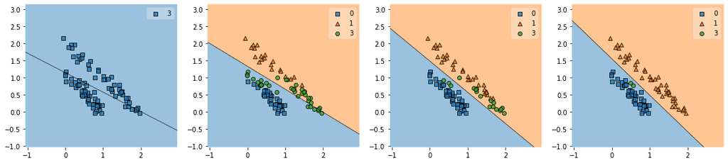

```python
fig, gs = plt.figure(figsize=(19,4)), gridspec.GridSpec(1, 4)

ax = []
factor = 2
for i in range(4):
    ax.append(fig.add_subplot(gs[i]))
    X_plot = U
    Y_plot = 3*np.ones(len(U), dtype=int)
    Y_plot[datas[factor*i][2]] = classes[datas[factor*i][2]]
    plot_decision_regions(X_plot, Y_plot, models[factor*i], ax=ax[i])

plt.show()
```

## Работа с неразмеченными данными

### Постановка

Сейчас данных много. Модели стали сложные. В глубоком обучении также пытаються использовать неразмеченные данные. Общий подход к данной задачи следующий:

- $\mathcal{U} \subset \mathcal{X}$ --- большая неразмеченная выборка
- $\mathcal{D} \subset \mathcal{X}\times \mathcal{Y}$ --- небольшая размеченная выборка
- требуется построить отображение $f: \mathcal{X} \to \mathcal{Y}$

#### Суперпозиция

Предположение $f = c \circ h$ --- отображение есть суперпозия двух функций:

- $h$ --- генерация признакового описания $h: \mathcal{X} \to \mathcal{H}$;
- $c$ --- классификатор $c: \mathcal{H} \to \mathcal{Y}$.

Заметим, что $c$ и $h$ например это некоторое параметрические функции, параметры которых нужно найти.

Простой пример:

- $h$ --- все слои полносвязного многослойного перцептрона;
- $c$ --- последний слой.

Обычно $h$ является сложной моделью, а $c$ --- линейной.

### Полносвязная нейронная сеть (Персептрон)

[figure not shown]

### Разложили в суперпозицию, что теперь?

Найдем сначала функцию $h$:

- Автоэнкодер (следующий семестр);
- Решим вспомагательную задачу на неразмеченных данных;

Имея $h$ найдем $c$:

- решаем, простую задачу оптимизаци для размеченных данных.

### Нахождения $h$

Поставим вспомагательную задачу:

- рассмотрим некоторую функцию $\mu': \mathcal{X} \to \mathcal{Y}',$ которая нам известна!
- получим выборку $\mathcal{D} = \left(U,\mu'\bigr(U\bigr) \right)$ --- большая размеченная колекция
- найдем фукнцию $f': \mathcal{X} \to \mathcal{Y}'$, где $f' = c' \circ h$.

Проблемы:

- Выбор функции $\mu'$.

### Задача оптимизации

Первый вариант: $$ \sum_{i=1}^{l} q(u_i, y_i', c', h) \to \min_{c', h}, $$ $$ \sum_{i=1}^{k} q(x_i, y_i, c, h) \to \min_{c}, $$

Второй вариант: $$ \lambda\sum_{i=1}^{l} q(u_i, y_i', c', h) + \left(1-\lambda\right)\sum_{i=1}^{k} q(x_i, y_i, c, h) \to \min_{c, h, c'}, $$ где $\lambda \in [0, 1]$